# Assignment 3

```r
data <- read.csv("Data/MPL.csv", na.strings = "NA")
median_MPL_01 <- median(data$MPL_conc[data$dose==0.1], na.rm=T)
median_MPL_01
```

```
## [1] 14.59
```

```r
median_MPL_03 <- median(data$MPL_conc[data$dose==0.3], na.rm=T)
median_MPL_03
```

```
## [1] 39.925
```

```r
medians <- aggregate(data[,c("MPL_conc","mRNA","Free_receptor")],list(data$dose,data$time), median, na.rm=T)
names(medians)[1:2] <- c("dose","time")
head(medians)
```

|  | dose | time | MPL_conc | mRNA | Free_receptor |
| --- | --- | --- | --- | --- | --- |
| 1 | 0.0 | 0 | 0.000 | 3.7900 | 292.95 |
| 2 | 0.1 | 6 | 11.180 | 1.7025 | 124.70 |
| 3 | 0.3 | 6 | 31.295 | 1.7295 | 97.90 |
| 4 | 0.1 | 10 | 12.335 | 1.7515 | 157.80 |
| 5 | 0.3 | 10 | 36.960 | 1.4140 | 69.55 |
| 6 | 0.1 | 13 | 11.945 | 1.7045 | 152.50 |

```r
data_low_dose <- subset(data, dose != 0.3)
data_high_dose <- subset(data, dose != 0.1)

median_low_dose <- subset(medians, dose != 0.3)
median_high_dose <- subset(medians, dose != 0.1)
head(median_low_dose)
```

|  | dose | time | MPL_conc | mRNA | Free_receptor |
| --- | --- | --- | --- | --- | --- |
| 1 | 0.0 | 0 | 0.000 | 3.7900 | 292.95 |
| 2 | 0.1 | 6 | 11.180 | 1.7025 | 124.70 |
| 4 | 0.1 | 10 | 12.335 | 1.7515 | 157.80 |
| 6 | 0.1 | 13 | 11.945 | 1.7045 | 152.50 |
| 8 | 0.1 | 18 | 29.270 | 2.6270 | 97.55 |
| 10 | 0.1 | 24 | 13.080 | 1.2055 | 74.25 |

```r
head(median_high_dose)
```

|  | dose | time | MPL_conc | mRNA | Free_receptor |
| --- | --- | --- | --- | --- | --- |
| 1 | 0.0 | 0 | 0.000 | 3.7900 | 292.95 |
| 3 | 0.3 | 6 | 31.295 | 1.7295 | 97.90 |
| 5 | 0.3 | 10 | 36.960 | 1.4140 | 69.55 |
| 7 | 0.3 | 13 | 31.970 | 1.6905 | 34.30 |
| 9 | 0.3 | 18 | 46.300 | 1.5380 | 26.25 |
| 11 | 0.3 | 24 | 51.975 | 0.9330 | 31.85 |

## Assignment 1: assess model validity

You have to compare the data from the experiment with the simulation data, to assess the model validity. The best way to do this is plotting the model results and the experimental results in one graph. The model results have one value per time unit, the experimental results have multiple values per time unit. Either plot all data points of the experimental data using a scatterplot or calculate the median results for each time unit and plot a line of these median points. You can do this for instance with the function aggregate.

## Questions:

[1] Why is it best practice to plot the median for the experimental data? Explain in your report The reason why it’s best to plot with the median is that it gives a representation of the central value.

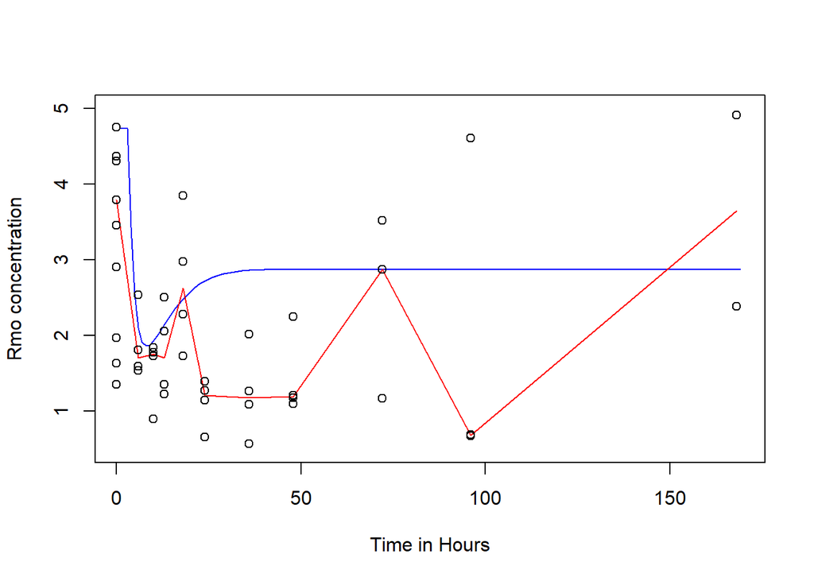

```r
library("deSolve")

D <- (median_MPL_01 * 1000)/374.471
parameters <- c(Ks_rm = 2.90, ic50_rm = 26.2, Kon = 0.00329, Kt = 0.63, Kre = 0.57, Rf = 0.49, Kd_R = 0.0572, Kd_Rm = 0.612, Ks_r = 3.22, D = D)
state <- c(Rmo = 4.74, Ro = 267, DR = 0, DRN = 0)
times <- seq(0, 168,  by = 1)

Grd_model <- function(t, y, parms){
  with(as.list(c(parms, y)),{
    Rmo.delta <- Ks_rm * (1-(DRN / (ic50_rm + DRN)))- Kd_Rm * Rmo
    R.delta <- Ks_r *  Rmo + Rf * Kre * DRN - Kon * D * Ro - Kd_R * Ro
    DR.delta <- Kon * D * Ro - Kt * DR
    DRN.delta <- Kt * DR - Kre * DRN

        return(list(c(Rmo.delta, R.delta, DR.delta, DRN.delta)))
       })
}


out <- ode(times = times, y = state,   parms = parameters, func = Grd_model, method = "euler")

plot(as.data.frame(out)$Rmo, type = "l", xlab = "Time in Hours", ylab = "Rmo concentration", ylim =  c(0.5,5.0), col = "blue")
lines(mRNA~time, data = median_low_dose, col = "red")
points(mRNA~time, data = data_low_dose)
```

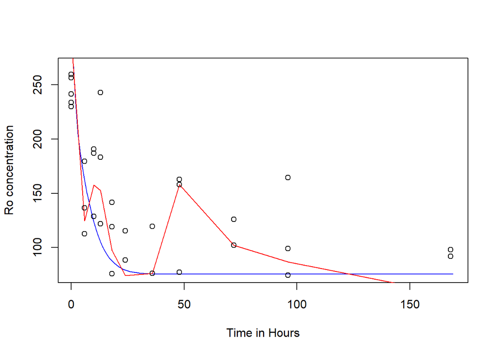

```r
plot(as.data.frame(out)$Ro, type = "l", xlab = "Time in Hours", ylab = "Ro concentration", col = "blue")
lines(Free_receptor~time, data = median_low_dose, col = "red")
points(Free_receptor~time, data = data_low_dose)
```

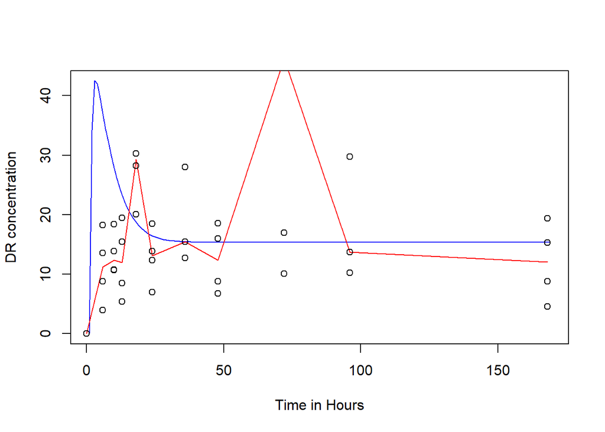

```r
plot(as.data.frame(out)$DR, type = "l", xlab = "Time in Hours", ylab = "DR concentration", col = "blue")
lines(MPL_conc~time, data = median_low_dose, col = "red")
points(MPL_conc~time, data = data_low_dose)
```

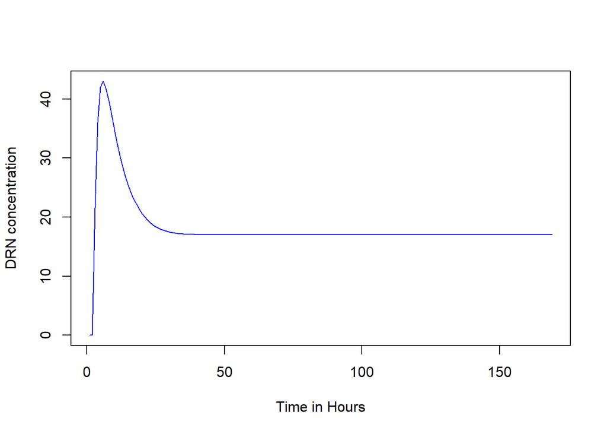

```r
plot(as.data.frame(out)$DRN, type = "l", xlab = "Time in Hours", ylab = "DRN concentration", col = "blue")
```

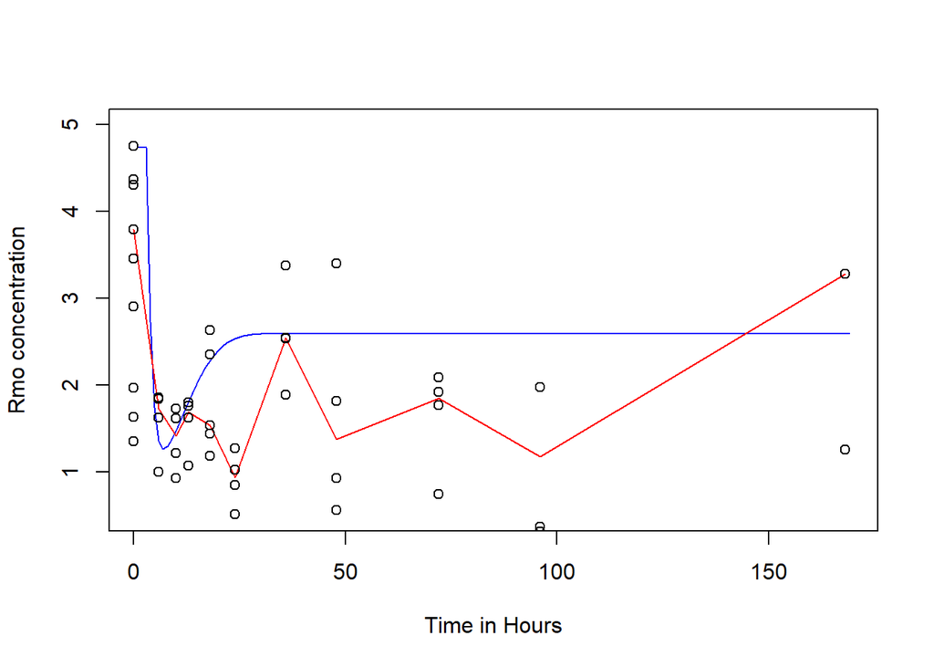

```r
D <- (median_MPL_03 * 1000)/374.471
parameters <- c(Ks_rm = 2.90, ic50_rm = 26.2, Kon = 0.00329, Kt = 0.63, Kre = 0.57, Rf = 0.49, Kd_R = 0.0572, Kd_Rm = 0.612, Ks_r = 3.22, D = D)

out <- ode(times = times, y = state,   parms = parameters, func = Grd_model, method = "euler")

plot(as.data.frame(out)$Rmo, type = "l", xlab = "Time in Hours", ylab = "Rmo concentration", ylim =  c(0.5,5.0), col = "blue")
lines(mRNA~time, data = median_high_dose, col = "red")
points(mRNA~time, data = data_high_dose)
```

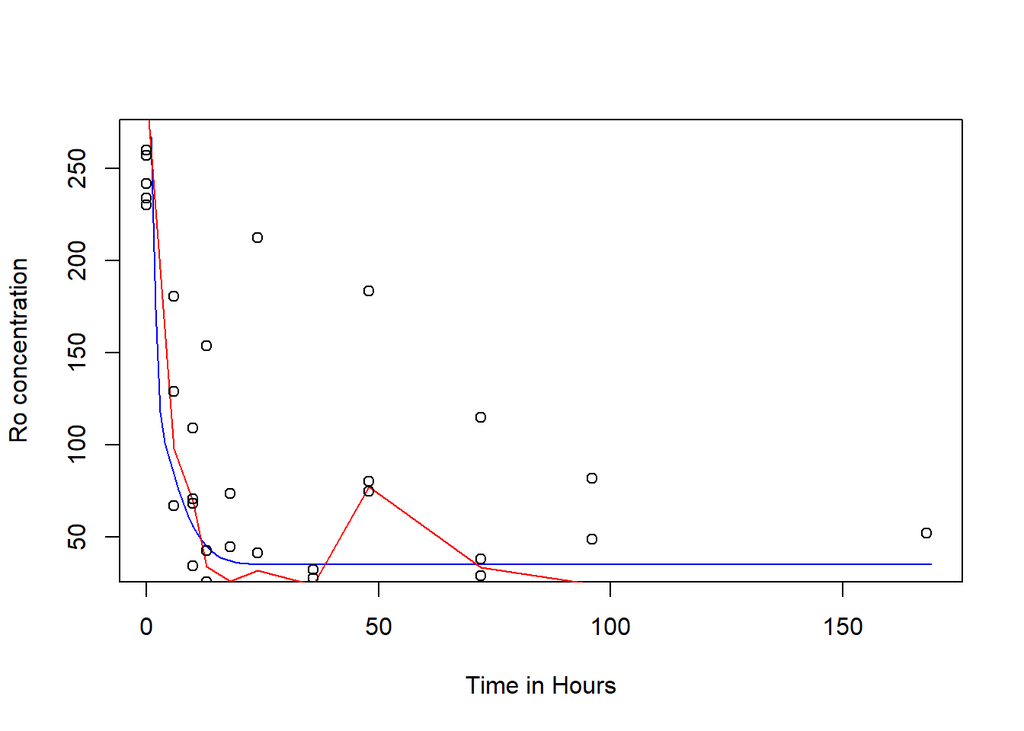

```r
plot(as.data.frame(out)$Ro, type = "l", xlab = "Time in Hours", ylab = "Ro concentration", col = "blue")
lines(Free_receptor~time, data = median_high_dose, col = "red")
points(Free_receptor~time, data = data_high_dose)
```

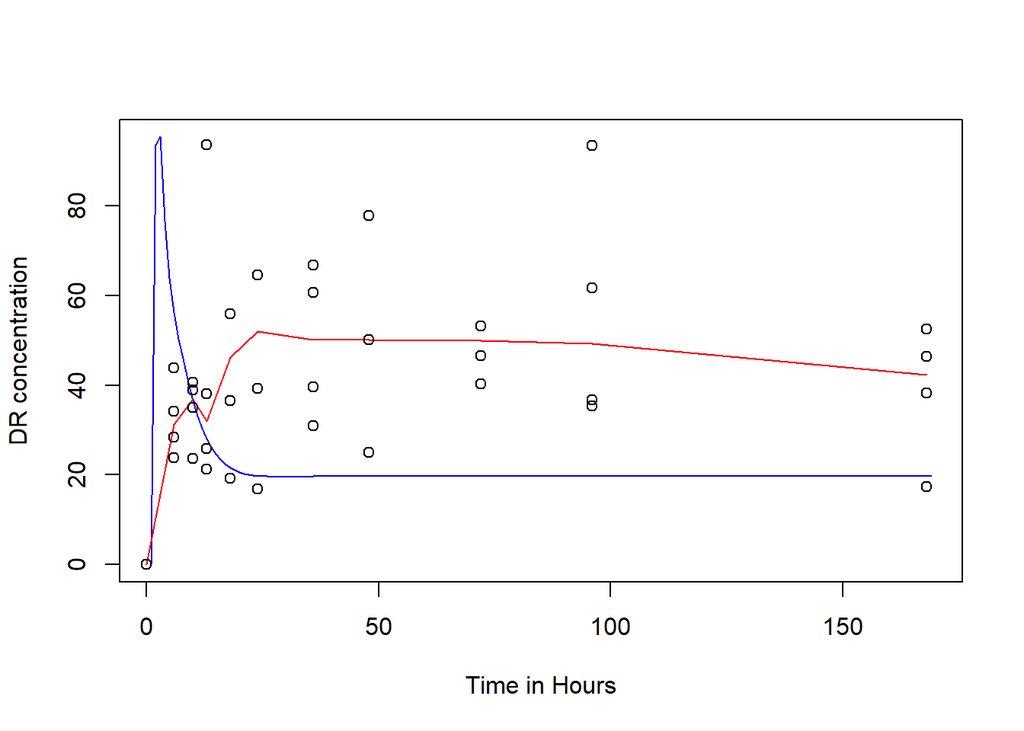

```r
plot(as.data.frame(out)$DR, type = "l", xlab = "Time in Hours", ylab = "DR concentration", col = "blue")
lines(MPL_conc~time, data = median_high_dose, col = "red")
points(MPL_conc~time, data = data_high_dose)
```

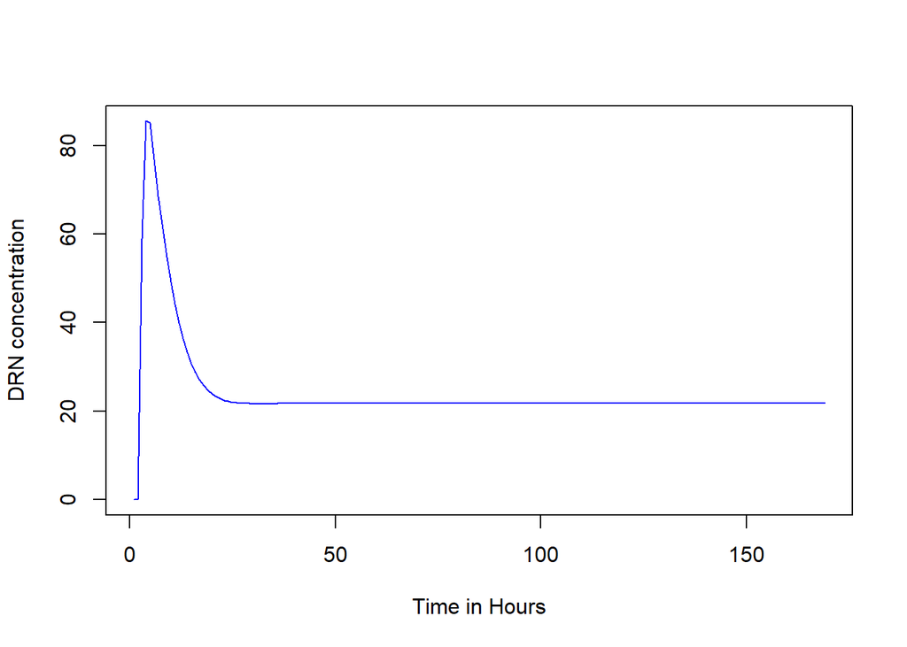

```r
plot(as.data.frame(out)$DRN, type = "l", xlab = "Time in Hours", ylab = "DRN concentration", col = "blue")
```

[2] How do the results of the simulations depend on the dose and concentration of the drug? Compare the model variables mRNA, R with the experimental data by running the simulations adjusting dosis D and plot these to find the answer. With both doses, we can see that the mRNA concentration follows the same trend as the model, it decreases and then increases again. However, it’s notable that with at both dose levels the mRNA doesn’t stabilise like the model, and it performs a yoyo-effect before the mRNA stabilises in an upwards climb. [3] Are the results of the model in line with experimental data? If not, what could be the reason? Think of at least one explanation. Try to test it with simulations (you will get bonus points for that, your explanation does not need to be correct, but should be logical).

# Assignment 2: simulate scenario’s

You are going to check what happens if you change the model and model parameters and compare the results to the basic scenario (from week 2). Unless stated otherwise, in the simulations for the solutions to this part, the values of different parameters and initial conditions should be as in the table in the assignments document. Value of kd_Rm should be 0.612, value of ks_r=3.22, value of D=20*1000/374.471.

## Questions:

[1] What would be the time course concentration of the activated drug-receptor complex if there was no auto-regulation of glucocorticoid receptor, i.e. if there was not effect of drug on the synthesis of the receptor mRNA? What formula needs to be changed? Adjust the model, run the simulation and plot the results to find out.

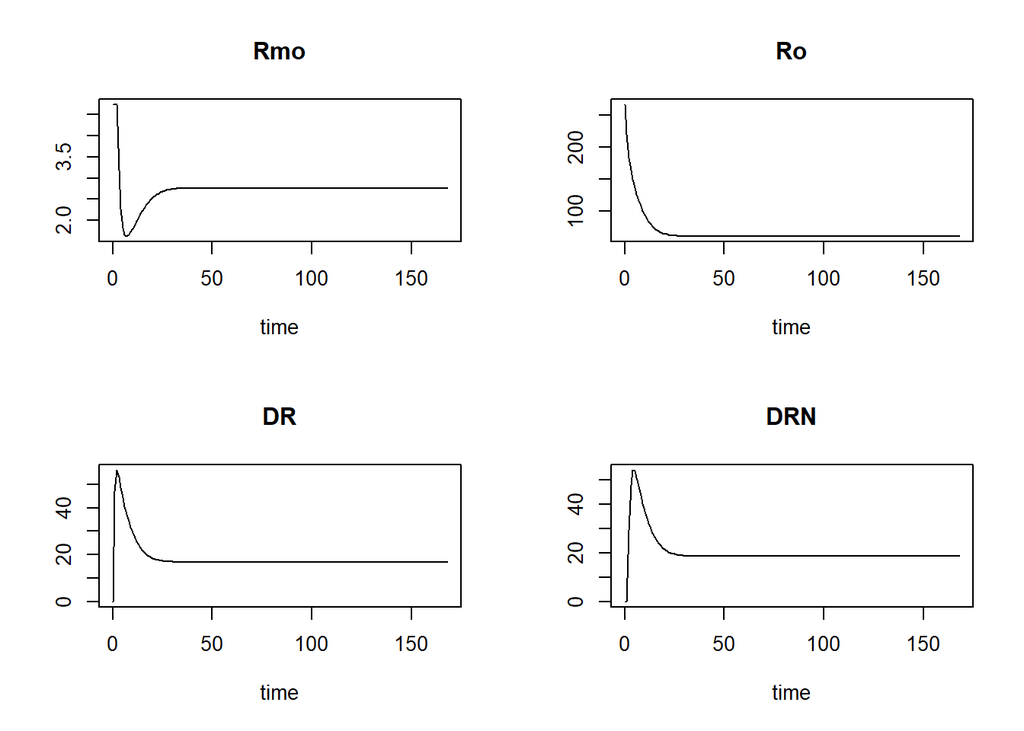

```r
D <- (20 * 1000)/374.471
parameters <- c(Ks_rm = 2.90, ic50_rm = 26.2, Kon = 0.00329, Kt = 0.63, Kre = 0.57, Rf = 0.49, Kd_R = 0.0572, Kd_Rm = 0.612, Ks_r = 3.22, D = D)
state <- c(Rmo = 4.74, Ro = 267, DR = 0, DRN = 0)
times <- seq(0, 168,  by = 1)

Grd_model <- function(t, y, parms){
  with(as.list(c(parms, y)),{
    Rmo.delta <- Ks_rm * (1-(DRN / (ic50_rm + DRN)))- Kd_Rm * Rmo
    R.delta <- Ks_r *  Rmo + Rf * Kre * DRN - Kon * D * Ro - Kd_R * Ro
    DR.delta <- Kon * D * Ro - Kt * DR
    DRN.delta <- Kt * DR - Kre * DRN

        return(list(c(Rmo.delta, R.delta, DR.delta, DRN.delta)))
       })
}


out <- ode(times = times, y = state,   parms = parameters, func = Grd_model, method = "euler")

plot(out)
```

[2] What is the time course of receptor and mRNA concentrations when the drug treatment is stopped? So After the steady state is reached (at time t_steady), D should be set to zero and the simulation should continue from time t_steady till the new steady state is reached (t_steady_second). Run the simulations and plot the results from t = 0 till t_steady_second.

```r
D <- (20 * 1000)/374.471
parameters <- c(Ks_rm = 2.90, ic50_rm = 26.2, Kon = 0.00329, Kt = 0.63, Kre = 0.57, Rf = 0.49, Kd_R = 0.0572, Kd_Rm = 0.612, Ks_r = 3.22, D = D)
state <- c(Rmo = 4.74, Ro = 267, DR = 0, DRN = 0)
times <- seq(0, 168,  by = 1)

Grd_model <- function(t, y, parms){
  with(as.list(c(parms, y)),{
    Rmo.delta <- Ks_rm * (1-(DRN / (ic50_rm + DRN)))- Kd_Rm * Rmo
    R.delta <- Ks_r *  Rmo + Rf * Kre * DRN - Kon * D * Ro - Kd_R * Ro
    DR.delta <- Kon * D * Ro - Kt * DR
    DRN.delta <- Kt * DR - Kre * DRN
    print(DR.delta)
    print(parms)
    if (DR.delta < 0.1) {
      D <<-  0
      parameters <<- c(Ks_rm = 2.90, ic50_rm = 26.2, Kon = 0.00329, Kt = 0.63, Kre = 0.57, Rf = 0.49, Kd_R = 0.0572, Kd_Rm = 0.612, Ks_r = 3.22, D = 0)
    }

        return(list(c(Rmo.delta, R.delta, DR.delta, DRN.delta)))
       })
}


out <- ode(times = times, y = state,   parms = parameters, func = Grd_model, method = "euler")
```

[output not shown]

[output cut: 790 more lines]

[output not shown]

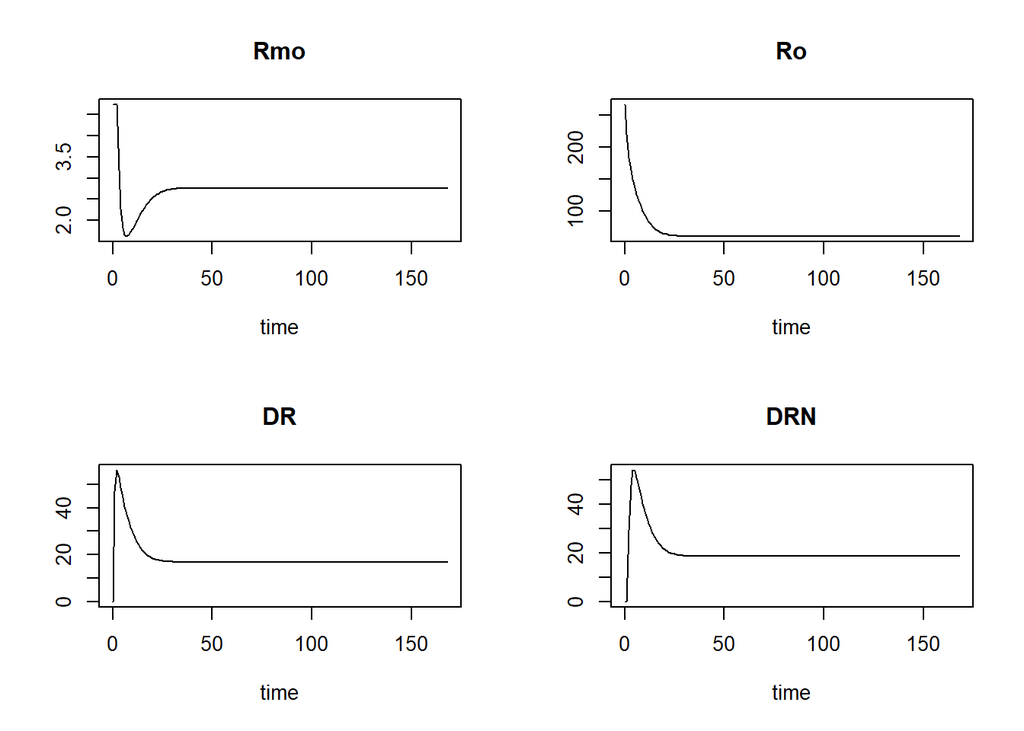

```r
plot(out)
```

[3] Different corticosteroids show different association rates from receptors (kon) and different dissociation rates (in this model reflected by kre). Assuming the same concentrations of the drug, what is the effect of different values of kon and kre (consider 2 and 5 times increase and decrease of both parameters separately) on the receptor and mRNA dynamics? Adjust kon and kre as below and plot the results of the simulation for each change. Note: Simulations should be run for 4 new values of kon: 0.00329/5, 0.00329/2, 0.00329*2 and 0.00329*5. The results should be compared to the basic scenario when kon=0.00329 Separately, simulations should be run for 4 new values of kre: 0.57/5, 0.57/2, 0.57*2 and 0.57*5. The results should be compared to the basic scenario when kre= 0.57.

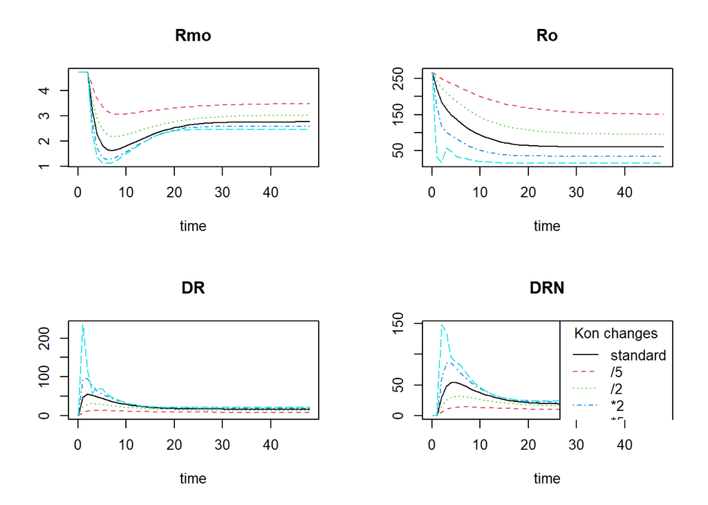

```r
D <- (20 * 1000)/374.471
parameters <- c(Ks_rm = 2.90, ic50_rm = 26.2, Kon = 0.00329, Kt = 0.63, Kre = 0.57, Rf = 0.49, Kd_R = 0.0572, Kd_Rm = 0.612, Ks_r = 3.22, D = D)
state <- c(Rmo = 4.74, Ro = 267, DR = 0, DRN = 0)
times <- seq(0, 48,  by = 1)

Grd_model <- function(t, y, parms){
  with(as.list(c(parms, y)),{
    Rmo.delta <- Ks_rm * (1-(DRN / (ic50_rm + DRN)))- Kd_Rm * Rmo
    R.delta <- Ks_r *  Rmo + Rf * Kre * DRN - Kon * D * Ro - Kd_R * Ro
    DR.delta <- Kon * D * Ro - Kt * DR
    DRN.delta <- Kt * DR - Kre * DRN

        return(list(c(Rmo.delta, R.delta, DR.delta, DRN.delta)))
       })
}

#  Standard Kon
out <- ode(times = times, y = state, parms = parameters, func = Grd_model, method = "euler")

# Setting kon to 0.0329/5
parameters["Kon"] <- 0.00329/5
out2 <- ode(times = times, y = state, parms = parameters, func = Grd_model, method = "euler")

# setting Kon to 0.0329/2
parameters["Kon"] <- 0.00329/2
out3 <- ode(times = times, y = state, parms = parameters, func = Grd_model, method = "euler")

# setting Kon to 0.0329*2
parameters["Kon"] <- 0.00329*2
out4 <- ode(times = times, y = state, parms = parameters, func = Grd_model, method = "euler")

# setting Kon to 0.0329*5
parameters["Kon"] <- 0.00329*5
out5 <- ode(times = times, y = state, parms = parameters, func = Grd_model, method = "euler")

# Plotting everything Kon related
plot(out, out2, out3, out4, out5)
legend("topright", lty = 1:5, col = 1:5, legend = c("standard", "/5", "/2", "*2", "*5"), title= "Kon changes")
```

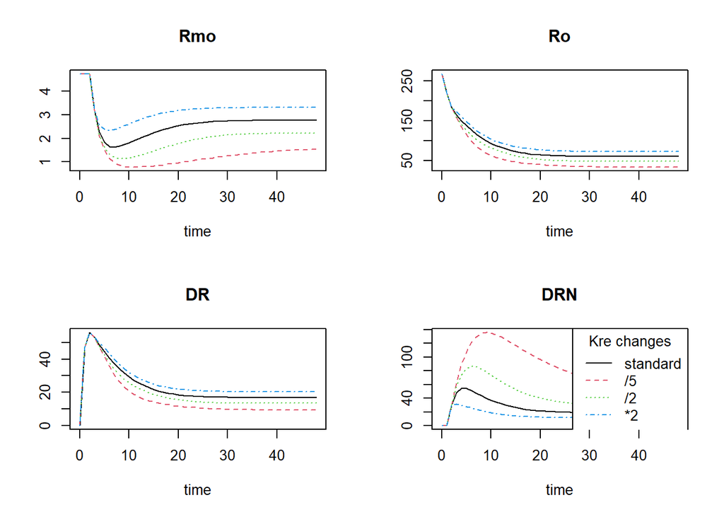

```r
# Resetting Kon to default value and running standard kre
parameters["Kon"] <- 0.00329
out <- ode(times = times, y = state, parms = parameters, func = Grd_model, method = "euler")

# setting kre to 0.57/5
parameters["Kre"] <- 0.57/5
out2 <- ode(times = times, y = state, parms = parameters, func = Grd_model, method = "euler")

# setting kre to 0.57/2
parameters["Kre"] <- 0.57/2
out3 <- ode(times = times, y = state, parms = parameters, func = Grd_model, method = "euler")

# setting kre to 0.57*2
parameters["Kre"] <- 0.57*2
out4 <- ode(times = times, y = state, parms = parameters, func = Grd_model, method = "euler")

# setting kre to 0.57*5
parameters["Kre"] <- 0.57*5
out5 <- ode(times = times, y = state, parms = parameters, func = Grd_model, method = "euler")

# Plotting everything Kre related
plot(out, out2, out3, out4)
legend("topright", lty = 1:4, col = 1:4, legend = c("standard", "/5", "/2", "*2"), title= "Kre changes")
```

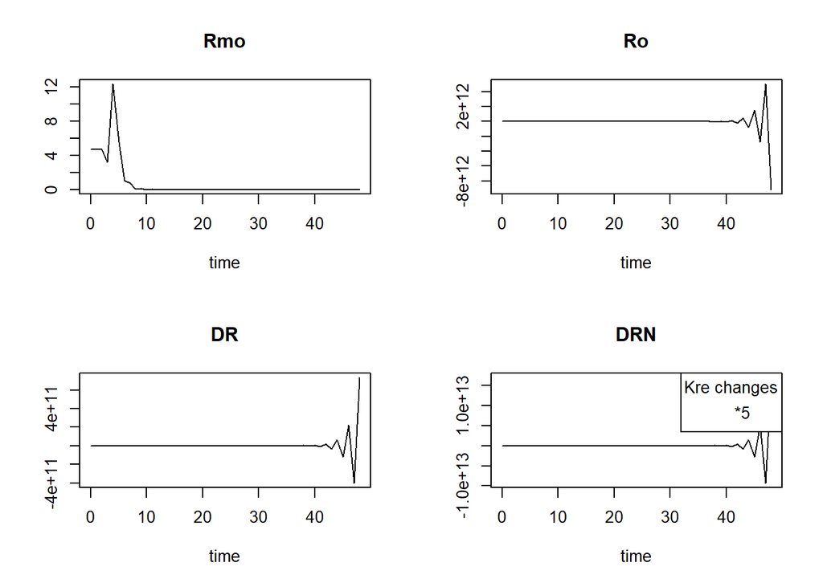

```r
# plotted this scenario sepertately due to the value difference, it would ruin the plots
plot(out5)
legend("topright", legend = "*5", title = "Kre changes")
```

[4] What would happen if the synthesis of the receptor was completely blocked? Which parameter needs to be put to zero? Adjust the parameter, run the simulations and plot the results.

Ks_rm needs to be set to zero, as this is the constant for mRNA synthesis.

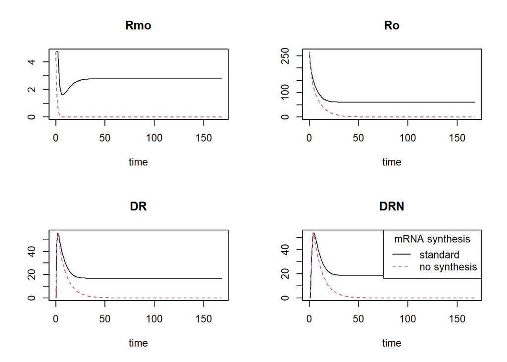

```r
D <- (20 * 1000)/374.471
parameters <- c(Ks_rm = 2.90, ic50_rm = 26.2, Kon = 0.00329, Kt = 0.63, Kre = 0.57, Rf = 0.49, Kd_R = 0.0572, Kd_Rm = 0.612, Ks_r = 3.22, D = D)
state <- c(Rmo = 4.74, Ro = 267, DR = 0, DRN = 0)
times <- seq(0, 168,  by = 1)

Grd_model <- function(t, y, parms){
  with(as.list(c(parms, y)),{
    Rmo.delta <- Ks_rm * (1-(DRN / (ic50_rm + DRN)))- Kd_Rm * Rmo
    R.delta <- Ks_r *  Rmo + Rf * Kre * DRN - Kon * D * Ro - Kd_R * Ro
    DR.delta <- Kon * D * Ro - Kt * DR
    DRN.delta <- Kt * DR - Kre * DRN

        return(list(c(Rmo.delta, R.delta, DR.delta, DRN.delta)))
       })
}

# standard plot
out <- ode(times = times, y = state,   parms = parameters, func = Grd_model, method = "euler")

# setting mRNA synthesis to 0 (ks_Rm)
parameters["Ks_rm"] <- 0
out2 <- ode(times = times, y = state,   parms = parameters, func = Grd_model, method = "euler")

plot(out, out2)
legend("topright", lty = 1:2, col = 1:2, legend = c("standard", "no synthesis"), title = "mRNA synthesis")
```

[5] What is the dynamic of the system when the baseline rate of production of mRNA of the receptor is increased or decreased 2 or 5 fold (recalculate the rate of mRNA degradation so that the steady-state assumption at baseline (without the drug) is still valid, i.e. mRNA levels are constant when there is not drug)? Mind you: ks_Rm values should be changed, but we know that if without the drug the system is at steady-state then kd_Rm = ks_Rm/Rm0. Therefore if we change ks_Rm we need to change kd_Rm as well. Also after we recalculate the value of kd_Rm for the baseline conditions, the simulations should be run with drug present. Simulations should be run for 4 different scenarios: ks_Rm = 2.9/5 and kd_Rm=2.9/5/4.74 ks_Rm = 2.9/2 and kd_Rm=2.9/2/4.74 ks_Rm = 2.9*2 and kd_Rm=2.9*2/4.74 ks_Rm = 2.9*5 and kd_Rm=2.9*5/4.74

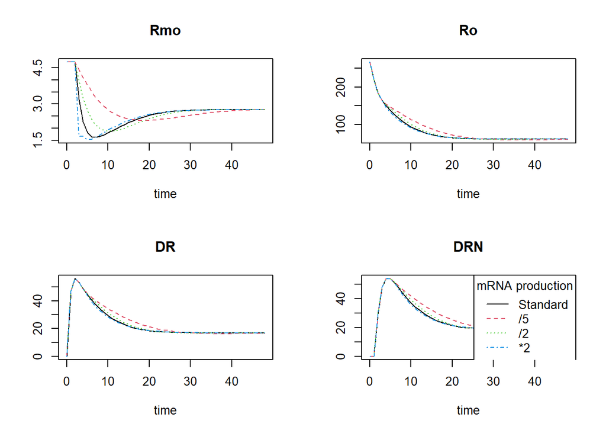

```r
D <- (20 * 1000)/374.471
parameters <- c(Ks_rm = 2.90, ic50_rm = 26.2, Kon = 0.00329, Kt = 0.63, Kre = 0.57, Rf = 0.49, Kd_R = 0.0572, Kd_Rm = 0.612, Ks_r = 3.22, D = D)
state <- c(Rmo = 4.74, Ro = 267, DR = 0, DRN = 0)
times <- seq(0, 48,  by = 1)

Grd_model <- function(t, y, parms){
  with(as.list(c(parms, y)),{
    Rmo.delta <- Ks_rm * (1-(DRN / (ic50_rm + DRN)))- Kd_Rm * Rmo
    R.delta <- Ks_r *  Rmo + Rf * Kre * DRN - Kon * D * Ro - Kd_R * Ro
    DR.delta <- Kon * D * Ro - Kt * DR
    DRN.delta <- Kt * DR - Kre * DRN

        return(list(c(Rmo.delta, R.delta, DR.delta, DRN.delta)))
       })
}

# standard scenario
out <- ode(times = times, y = state,   parms = parameters, func = Grd_model, method = "euler")

# rate of production divided by 5
parameters["Ks_rm"] <- 2.9/5
parameters["Kd_Rm"] <- parameters["Ks_rm"]/4.74
out2 <- ode(times = times, y = state,   parms = parameters, func = Grd_model, method = "euler")

# rate of production divided by 2
parameters["Ks_rm"] <- 2.9/2
parameters["Kd_Rm"] <- parameters["Ks_rm"]/4.74
out3 <- ode(times = times, y = state,   parms = parameters, func = Grd_model, method = "euler")

# rate of production multiplied by 2
parameters["Ks_rm"] <- 2.9*2
parameters["Kd_Rm"] <- parameters["Ks_rm"]/4.74
out4 <- ode(times = times, y = state,   parms = parameters, func = Grd_model, method = "euler")

# rate of production multiplied by 5
parameters["Ks_rm"] <- 2.9*5
parameters["Kd_Rm"] <- parameters["Ks_rm"]/4.74
out5 <- ode(times = times, y = state,   parms = parameters, func = Grd_model, method = "euler")

plot(out, out2, out3, out4)
legend("topright", lty = 1:4, col = 1:4, legend = c("Standard", "/5", "/2", "*2"), title = "mRNA production")
```

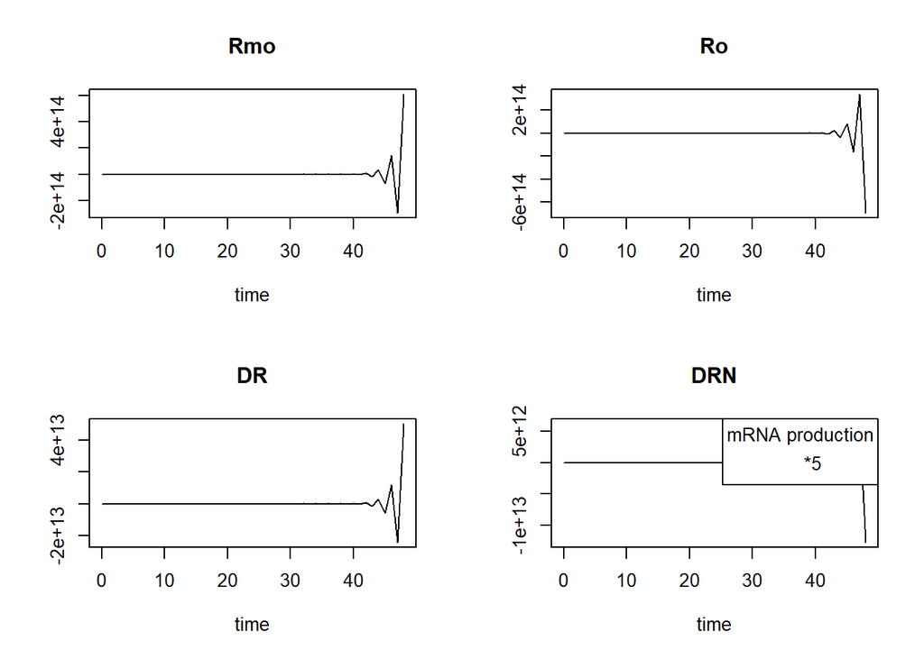

```r
# plotted this scenario sepertately due to the value difference, it would ruin the plots
plot(out5)
legend("topright", legend = "*5", title = "mRNA production")
```